# Hw1

name: ruoyu jin pittid: ruj10

## Task

Task: analyze dataset “Student Performance”. The objective is to explain the final grade (G3) in Math course in terms of the provided attributes.

### Task

#### 1.Q:

Read the data description.Check if there is missing value.Identify and report response variable and predictors (also called explanatory variables or features). Report the numerical variables and categorical variables in the dataset.

#### A:

- Missing Value: none
- Response: G3 - final grade (numeric: from 0 to 20, output target)
- predictors:

```r
student <- read.csv("student-mat.csv",header = TRUE, sep = ";")
names(student[,-length(student)])
```

```
##  [1] "school"     "sex"        "age"        "address"    "famsize"
##  [6] "Pstatus"    "Medu"       "Fedu"       "Mjob"       "Fjob"
## [11] "reason"     "guardian"   "traveltime" "studytime"  "failures"
## [16] "schoolsup"  "famsup"     "paid"       "activities" "nursery"
## [21] "higher"     "internet"   "romantic"   "famrel"     "freetime"
## [26] "goout"      "Dalc"       "Walc"       "health"     "absences"
## [31] "G1"         "G2"
```

- numerical: age, Medu, Fedu, traveltime, studytime, failures, famrel, freetime, goout, Dalc, Walc, health, absences, G1, G2, G3
- categorical:
  - binary: school,sex,address, famsize,Pstatus, schoolsup, famsup, paid, activities, nursery, higher, internet, romantic
  - nominal: Mjob, Fjob, reason, guardian

#### 2. Q:

Explore the data set,and generate both statistical and graphical summary. To simplify the task, only consider the following 10 variables in this exploration: age, address, Pstatus, activities, higher, internet, absences, G1, G2, G3.  
**Qa**. Generate a summary table for the numerical variables. For each one, list: **variable name, mean, median, 1st quartile, 3rd quartile, and standard deviation**.

#### A:

numerical variables: **age, absences, G1, G2, G3**

```r
summary1 <- apply(student[,c("age","absences","G1","G2","G3")], 2, summary)
sd <-apply(student[,c("age","absences","G1","G2","G3")], 2, sd)
result_a <- rbind(summary1,sd)
result_a
```

```
##               age  absences        G1        G2        G3
## Min.    15.000000  0.000000  3.000000  0.000000  0.000000
## 1st Qu. 16.000000  0.000000  8.000000  9.000000  8.000000
## Median  17.000000  4.000000 11.000000 11.000000 11.000000
## Mean    16.696203  5.708861 10.908861 10.713924 10.415190
## 3rd Qu. 18.000000  8.000000 13.000000 13.000000 14.000000
## Max.    22.000000 75.000000 19.000000 19.000000 20.000000
## sd       1.276043  8.003096  3.319195  3.761505  4.581443
```

#### Qb.

For numerical variables, plot the density distribution. Describe whether the variable has a normal distribution or certain type of skew distribution.

#### A:

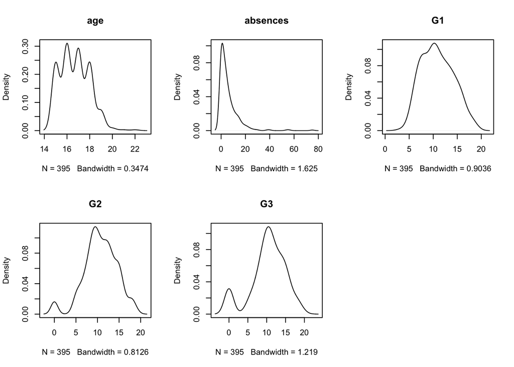

```r
par(mfrow=c(2,3))
plot(density(student$age), main = "age")
plot(density(student$absences),main = "absences")
plot(density(student$G1),main="G1")
plot(density(student$G2),main="G2")
plot(density(student$G3),main="G3")
```

age: postitive distribution  
absences: positive skew distribution  
G1: normal distribution  
G2: normal distribution  
G3: normal distribution

#### Qc.

For each numerical predictor, describe its relationship with the response variable through correlation and scatterplot.

#### A:

```r
numerical_data = as.data.frame(student[,c("G3", "G1",
                                     "G2", "absences", "age","studytime")])
cor(numerical_data)
```

```
##                    G3         G1         G2    absences          age
## G3         1.00000000  0.8014679  0.9048680  0.03424732 -0.161579438
## G1         0.80146793  1.0000000  0.8521181 -0.03100290 -0.064081497
## G2         0.90486799  0.8521181  1.0000000 -0.03177670 -0.143474049
## absences   0.03424732 -0.0310029 -0.0317767  1.00000000  0.175230079
## age       -0.16157944 -0.0640815 -0.1434740  0.17523008  1.000000000
## studytime  0.09781969  0.1606119  0.1358800 -0.06270018 -0.004140037
##              studytime
## G3         0.097819690
## G1         0.160611915
## G2         0.135879999
## absences  -0.062700175
## age       -0.004140037
## studytime  1.000000000
```

```r
cor(student$G3,student$G2)
```

```
## [1] 0.904868
```

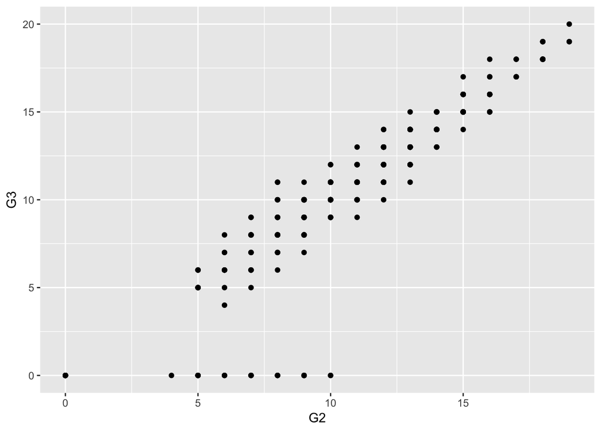

```r
library(ggplot2)
ggplot(student,aes(x=G2,y=G3))+geom_point()
```

```r
cor(student$G3,student$G1)
```

```
## [1] 0.8014679
```

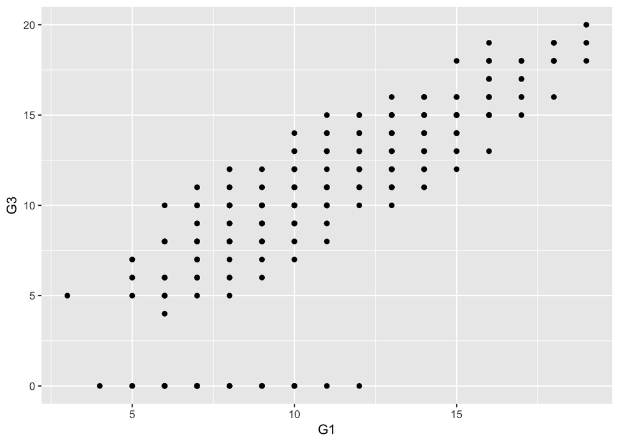

```r
library(ggplot2)
ggplot(student,aes(x=G1,y=G3))+geom_point()
```

```r
cor(student$G3,student$age)
```

```
## [1] -0.1615794
```

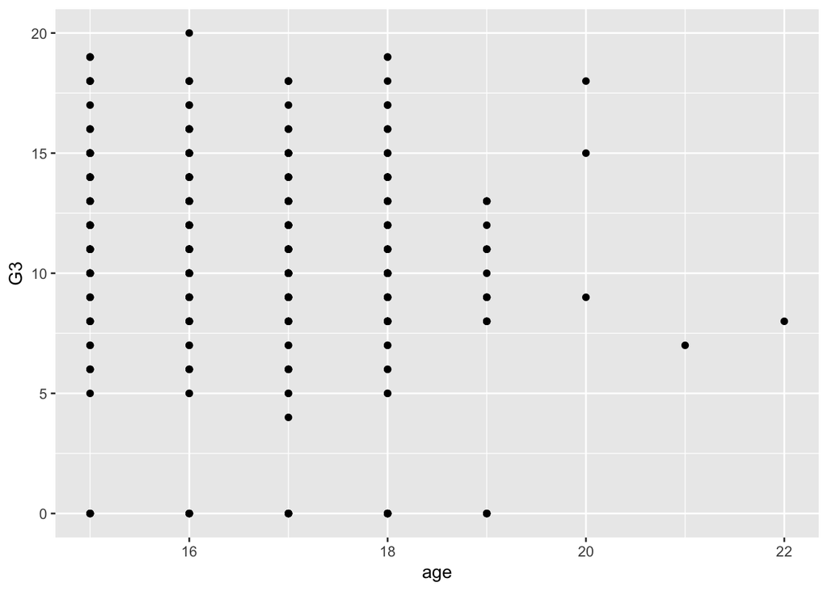

```r
library(ggplot2)
ggplot(student,aes(x=age,y=G3))+geom_point()
```

```r
cor(student$G3,student$absences)
```

```
## [1] 0.03424732
```

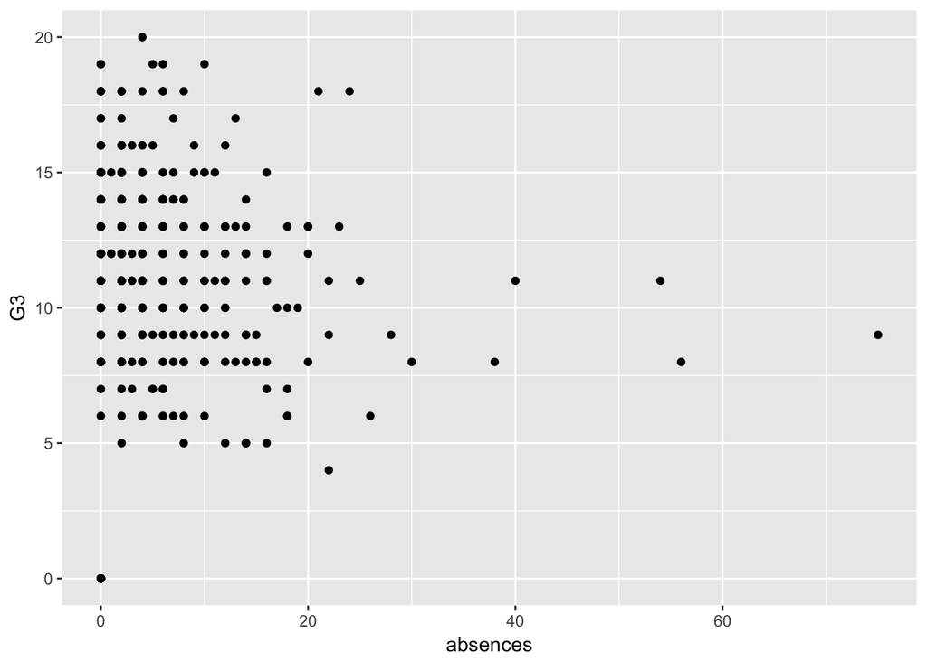

```r
library(ggplot2)
ggplot(student,aes(x=absences,y=G3))+geom_point()
```

#### Qd:

For each categorical predictor, generate their conditional density plot of response variable. Hint: Plot the density of response variable into multiple distributions separated by the predictor’s categories, on the same figure. Use different colors or line shapes to differentiate categories. Make sure to use the proper variable “type” for the categorical variables before plotting.

#### A:

categorical : address, Pstatus, activities, higher, internet,

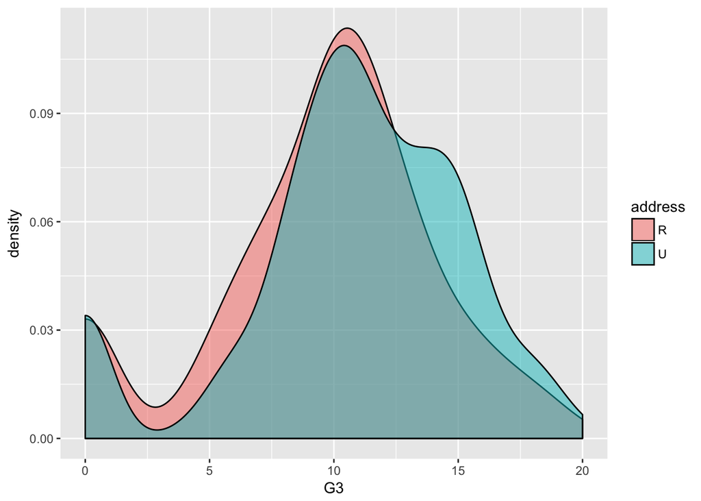

```r
library(ggplot2)
ggplot(student,aes(x = G3,fill= address))+geom_density(alpha = 0.5)
```

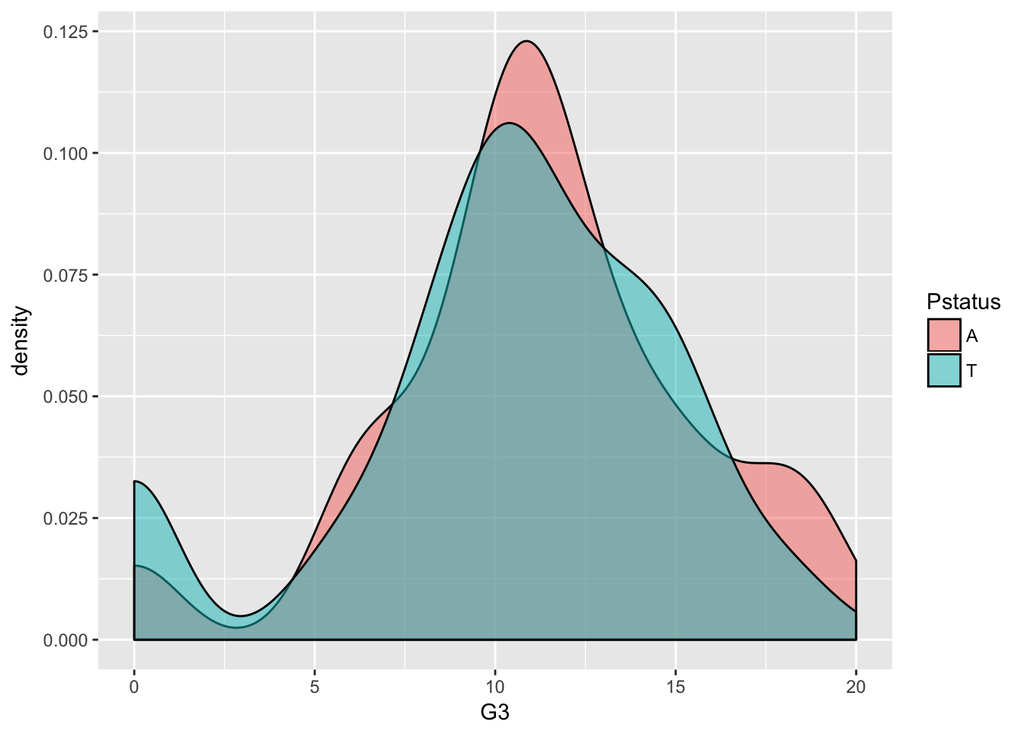

```r
library(ggplot2)
ggplot(student,aes(x = G3,fill= Pstatus))+geom_density(alpha = 0.5)
```

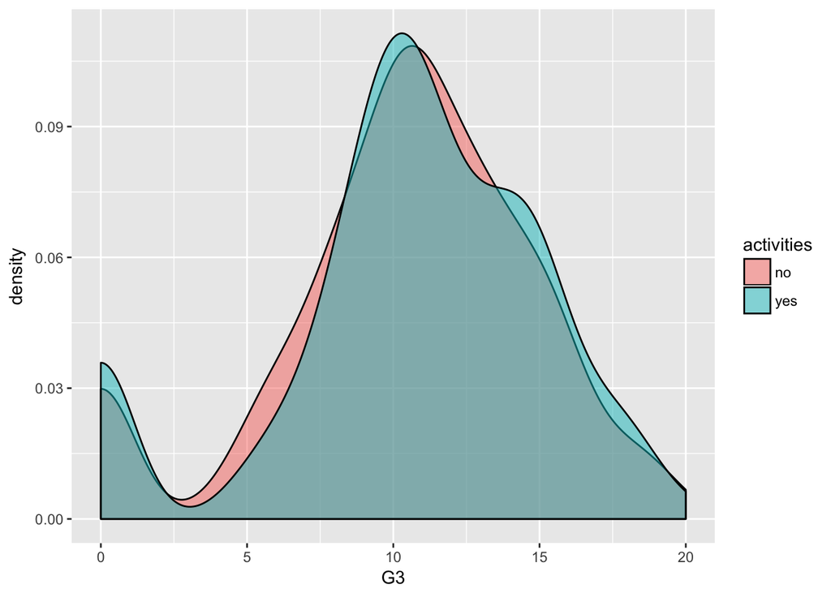

```r
library(ggplot2)
ggplot(student,aes(x = G3,fill= activities))+geom_density(alpha = 0.5)
```

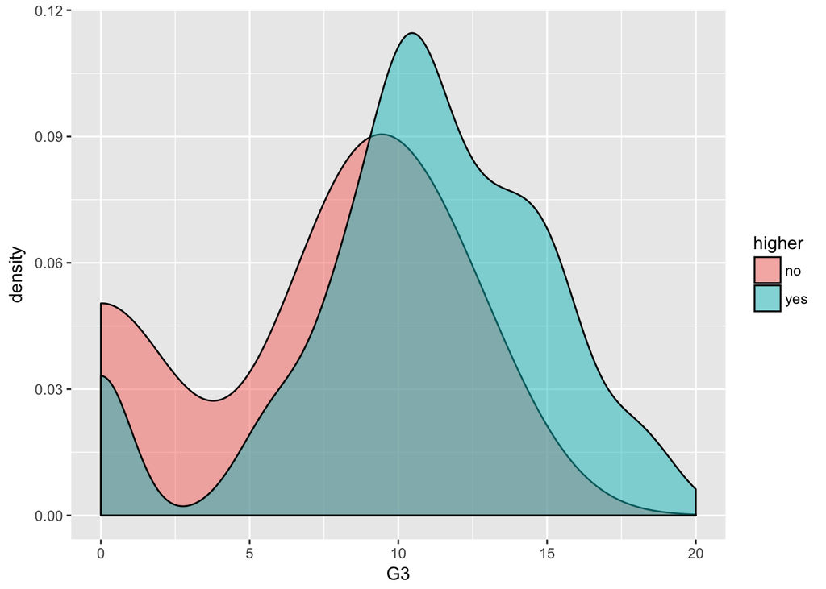

```r
library(ggplot2)
ggplot(student,aes(x = G3,fill= higher))+geom_density(alpha = 0.5)
```

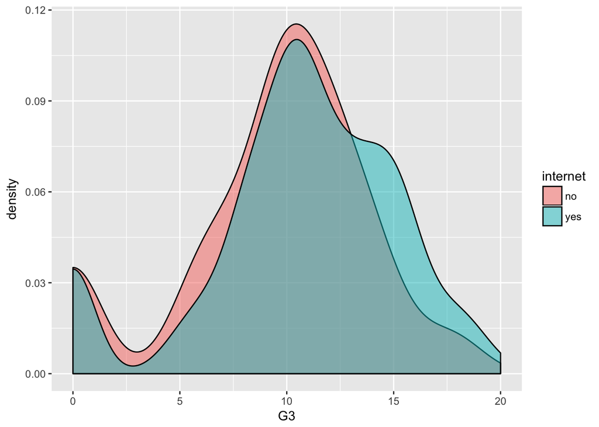

```r
library(ggplot2)
ggplot(student,aes(x = G3,fill= internet))+geom_density(alpha = 0.5)
```

#### Qe:

(extra points) Compare and describe whether the response variable is significantly different for students with and without extra-curricular activities.

#### A:

From the plot G3~activity we can see student with extra-curricular activities are more likely to have high G3. But that is not sigificantly I think.

#### 3.

Apply regression analysis on the data.Evaluate the model as well as the impact of different predictors.

#### Qa.

Use all predictors in a standard linear regression model to predict the response variable. Report the model performance using R2, adjusted R2 and RMSE. Interpret the regression result.

```r
fit = lm(G3~.,data=student)
summary(fit)
```

```
##
## Call:
## lm(formula = G3 ~ ., data = student)
##
## Residuals:
##     Min      1Q  Median      3Q     Max
## -7.9339 -0.5532  0.2680  0.9689  4.6461
##
## Coefficients:
##                   Estimate Std. Error t value Pr(>|t|)
## (Intercept)      -1.115488   2.116958  -0.527 0.598573
## schoolMS          0.480742   0.366512   1.312 0.190485
## sexM              0.174396   0.233588   0.747 0.455805
## age              -0.173302   0.100780  -1.720 0.086380 .
## addressU          0.104455   0.270791   0.386 0.699922
## famsizeLE3        0.036512   0.226680   0.161 0.872128
## PstatusT         -0.127673   0.335626  -0.380 0.703875
## Medu              0.129685   0.149999   0.865 0.387859
## Fedu             -0.133940   0.128768  -1.040 0.298974
## Mjobhealth       -0.146426   0.518491  -0.282 0.777796
## Mjobother         0.074088   0.332044   0.223 0.823565
## Mjobservices      0.046956   0.369587   0.127 0.898973
## Mjobteacher      -0.026276   0.481632  -0.055 0.956522
## Fjobhealth        0.330948   0.666601   0.496 0.619871
## Fjobother        -0.083582   0.476796  -0.175 0.860945
## Fjobservices     -0.322142   0.493265  -0.653 0.514130
## Fjobteacher      -0.112364   0.601448  -0.187 0.851907
## reasonhome       -0.209183   0.256392  -0.816 0.415123
## reasonother       0.307554   0.380214   0.809 0.419120
## reasonreputation  0.129106   0.267254   0.483 0.629335
## guardianmother    0.195741   0.252672   0.775 0.439046
## guardianother     0.006565   0.463650   0.014 0.988710
## traveltime        0.096994   0.157800   0.615 0.539170
## studytime        -0.104754   0.134814  -0.777 0.437667
## failures         -0.160539   0.161006  -0.997 0.319399
## schoolsupyes      0.456448   0.319538   1.428 0.154043
## famsupyes         0.176870   0.224204   0.789 0.430710
## paidyes           0.075764   0.222100   0.341 0.733211
## activitiesyes    -0.346047   0.205938  -1.680 0.093774 .
## nurseryyes       -0.222716   0.254184  -0.876 0.381518
## higheryes         0.225921   0.500398   0.451 0.651919
## internetyes      -0.144462   0.287528  -0.502 0.615679
## romanticyes      -0.272008   0.219732  -1.238 0.216572
## famrel            0.356876   0.114124   3.127 0.001912 **
## freetime          0.047002   0.110209   0.426 0.670021
## goout             0.012007   0.105230   0.114 0.909224
## Dalc             -0.185019   0.153124  -1.208 0.227741
## Walc              0.176772   0.114943   1.538 0.124966
## health            0.062995   0.074800   0.842 0.400259
## absences          0.045879   0.013412   3.421 0.000698 ***
## G1                0.188847   0.062373   3.028 0.002645 **
## G2                0.957330   0.053460  17.907  < 2e-16 ***
## ---
## Signif. codes:  0 '***' 0.001 '**' 0.01 '*' 0.05 '.' 0.1 ' ' 1
##
## Residual standard error: 1.901 on 353 degrees of freedom
## Multiple R-squared:  0.8458, Adjusted R-squared:  0.8279
## F-statistic: 47.21 on 41 and 353 DF,  p-value: < 2.2e-16
```

#### Q

Report the model performance using R2, adjusted R2 and RMSE. Interpret the regression result.

#### A

R2 and adjusted R2 are both high and RMSE is low, so the model fit well! according to the regression coefficients, G1, G2, absences, famrel have high weight compared to other predictors.

```r
model.mse = mean(residuals(fit)^2)
rmse = sqrt(model.mse)
rmse
```

```
## [1] 1.796979
```

#### Qb

Compare the standard linear regression models with three different set of predictors:  
* i. (Set A) school, sex, age, address, Pstatus, Medu, Fedu, Mjob, Fjob, traveltime, studytime, failures, absences, G1, G2.  
* ii. (Set B) school, sex, age, studytime, failures, absences, G1, G2.  
* iii. (Set C) school, sex, age, address, Pstatus, Medu, Fedu, Mjob, Fjob, traveltime, G1, G2. Evaluate which model performs better using out-of-sample RMSE. Hint: Implement leave-one-out cross-validation for out-of-sample evaluation.

#### A:

```r
n = length(student)
error_A = dim(n)
error_B = dim(n)
error_C = dim(n)
for(k in 1:n){

    train1 = c(1:n)
  train = train1[train1 != k]
  fit_A = lm(G3~school + sex + age + address + Pstatus + Medu + Fedu + Mjob + Fjob + traveltime + studytime + failures + absences + G1 + G2,data = student)
  fit_B = lm(G3~school + sex + age + failures + absences + G1 + G2,data = student)
  fit_C = lm(G3~school + sex + age + address + Pstatus + Medu + Fedu + Mjob + Fjob + traveltime + G1 + G2,data = student)
  pred_A = predict(fit_A,newdat=student[-train,])
  pred_B = predict(fit_B,newdat=student[-train,])
  pred_C = predict(fit_C,newdat=student[-train,])
    obs = student$G3[-train]
  error_A[k] = obs[1]-pred_A[1]
  error_B[k] = obs[1]-pred_B[1]
  error_C[k] = obs[1]-pred_C[1]
}
  sqrt(mean(error_A^2))
```

```
## [1] 1.091372
```

```r
  sqrt(mean(error_B^2))
```

```
## [1] 1.079751
```

```r
  sqrt(mean(error_C^2))
```

```
## [1] 1.046636
```

#### Qb:

build two different non-linear regression models with the predictors in SET C“. Just pick up some predictors you like, not necessarily all of them. Hint: Use poly, locfitor other appropriate packages for non-linear regression models. At least one of the predictors should have non-linear relationship with the response variable in a non-linear model.

#### A:

#### First model: poly with backward to get the best predictors.

```r
library(MASS)
back = lm(formula = G3 ~ poly(absences, degree = 2) + ., data = student)
stepAIC(back, direction="backward")
```

```
## Start:  AIC=530.67
## G3 ~ poly(absences, degree = 2) + (school + sex + age + address +
##     famsize + Pstatus + Medu + Fedu + Mjob + Fjob + reason +
##     guardian + traveltime + studytime + failures + schoolsup +
##     famsup + paid + activities + nursery + higher + internet +
##     romantic + famrel + freetime + goout + Dalc + Walc + health +
##     absences + G1 + G2)
##
##
## Step:  AIC=530.67
## G3 ~ poly(absences, degree = 2) + school + sex + age + address +
##     famsize + Pstatus + Medu + Fedu + Mjob + Fjob + reason +
##     guardian + traveltime + studytime + failures + schoolsup +
##     famsup + paid + activities + nursery + higher + internet +
##     romantic + famrel + freetime + goout + Dalc + Walc + health +
##     G1 + G2
##
##                              Df Sum of Sq    RSS    AIC
## - Mjob                        4      2.30 1219.9 523.42
## - Fjob                        4      3.68 1221.3 523.87
## - reason                      3      5.11 1222.7 526.33
## - guardian                    2      4.12 1221.7 528.01
## - famsize                     1      0.00 1217.6 528.68
## - goout                       1      0.15 1217.8 528.72
## - freetime                    1      0.22 1217.8 528.75
## - address                     1      0.32 1217.9 528.78
## - paid                        1      0.70 1218.3 528.90
## - higher                      1      0.92 1218.5 528.97
## - sex                         1      1.21 1218.8 529.06
## - Pstatus                     1      1.22 1218.8 529.07
## - famsup                      1      1.23 1218.8 529.07
## - internet                    1      1.27 1218.9 529.08
## - studytime                   1      1.29 1218.9 529.09
## - Medu                        1      1.81 1219.4 529.26
## - Fedu                        1      2.24 1219.8 529.40
## - traveltime                  1      2.33 1219.9 529.43
## - health                      1      4.57 1222.2 530.15
## - Walc                        1      5.07 1222.7 530.32
## - romantic                    1      5.60 1223.2 530.48
## - Dalc                        1      5.76 1223.4 530.54
```

[output cut: 658 more lines]

```
## Step:  AIC=484.5
## G3 ~ poly(absences, degree = 2) + school + age + failures + activities +
##     romantic + famrel + G1 + G2
##
##                              Df Sum of Sq    RSS    AIC
## <none>                                    1273.8 484.50
## - failures                    1      6.93 1280.7 484.64
## - romantic                    1      7.76 1281.6 484.90
## - school                      1      9.86 1283.7 485.54
## - activities                  1     12.86 1286.7 486.47
## - G1                          1     30.96 1304.8 491.98
## - age                         1     32.52 1306.3 492.45
## - famrel                      1     49.54 1323.3 497.57
## - poly(absences, degree = 2)  2    125.58 1399.4 517.64
## - G2                          1   1310.15 2583.9 761.89
```

```
##
## Call:
## lm(formula = G3 ~ poly(absences, degree = 2) + school + age +
##     failures + activities + romantic + famrel + G1 + G2, data = student)
##
## Coefficients:
##                 (Intercept)  poly(absences, degree = 2)1
##                      1.4875                       8.0885
## poly(absences, degree = 2)2                     schoolMS
##                     -8.3893                       0.5453
##                         age                     failures
##                     -0.2631                      -0.1980
##               activitiesyes                  romanticyes
##                     -0.3659                      -0.3081
##                      famrel                           G1
##                      0.4028                       0.1652
##                          G2
##                      0.9540
```

```r
sk = lm(formula = G3 ~ poly(absences, degree = 2) + school + age +
    failures + activities + romantic + famrel + G1 + G2, data = student)
summary(sk)
```

```
##
## Call:
## lm(formula = G3 ~ poly(absences, degree = 2) + school + age +
##     failures + activities + romantic + famrel + G1 + G2, data = student)
##
## Residuals:
##     Min      1Q  Median      3Q     Max
## -8.4180 -0.5521  0.2325  0.9983  4.0572
##
## Coefficients:
##                             Estimate Std. Error t value Pr(>|t|)
## (Intercept)                  1.48750    1.43808   1.034 0.301616
## poly(absences, degree = 2)1  8.08848    1.89871   4.260 2.57e-05 ***
## poly(absences, degree = 2)2 -8.38930    1.84491  -4.547 7.30e-06 ***
## schoolMS                     0.54527    0.31623   1.724 0.085465 .
## age                         -0.26311    0.08404  -3.131 0.001876 **
## failures                    -0.19797    0.13700  -1.445 0.149258
## activitiesyes               -0.36585    0.18578  -1.969 0.049640 *
## romanticyes                 -0.30811    0.20144  -1.530 0.126945
## famrel                       0.40278    0.10423   3.864 0.000131 ***
## G1                           0.16523    0.05408   3.055 0.002407 **
## G2                           0.95401    0.04800  19.874  < 2e-16 ***
## ---
## Signif. codes:  0 '***' 0.001 '**' 0.01 '*' 0.05 '.' 0.1 ' ' 1
##
## Residual standard error: 1.821 on 384 degrees of freedom
## Multiple R-squared:  0.846,  Adjusted R-squared:  0.842
## F-statistic: 210.9 on 10 and 384 DF,  p-value: < 2.2e-16
```

#### Secnod Model: Lasso

```r
library(lars)
lasso_data = data.matrix((student[,-length(student)]))
lasso_model = lars( x=lasso_data,y=student$G3,trace = TRUE)
```

```
## LASSO sequence
## Computing X'X .....
## LARS Step 1 :     Variable 32    added
## LARS Step 2 :     Variable 31    added
## LARS Step 3 :     Variable 24    added
## LARS Step 4 :     Variable 30    added
## LARS Step 5 :     Variable 15    added
## LARS Step 6 :     Variable 3     added
## LARS Step 7 :     Variable 23    added
## LARS Step 8 :     Variable 19    added
## LARS Step 9 :     Variable 28    added
## LARS Step 10 :    Variable 16    added
## LARS Step 11 :    Variable 14    added
## LARS Step 12 :    Variable 29    added
## LARS Step 13 :    Variable 10    added
## LARS Step 14 :    Variable 2     added
## LARS Step 15 :    Variable 13    added
## LARS Step 16 :    Variable 25    added
## LARS Step 17 :    Variable 1     added
## LARS Step 18 :    Variable 11    added
## LARS Step 19 :    Variable 6     added
## LARS Step 20 :    Variable 7     added
## LARS Step 21 :    Variable 20    added
## LARS Step 22 :    Variable 22    added
## LARS Step 23 :    Variable 17    added
## LARS Step 24 :    Variable 8     added
## LARS Step 25 :    Variable 12    added
## LARS Step 26 :    Variable 21    added
## LARS Step 27 :    Variable 27    added
## LARS Step 28 :    Variable 18    added
## LARS Step 29 :    Variable 9     added
## LARS Step 30 :    Variable 26    added
## LARS Step 31 :    Variable 5     added
## LARS Step 32 :    Variable 4     added
## Computing residuals, RSS etc .....
```

```r
lasso_model
```

```
##
## Call:
## lars(x = lasso_data, y = student$G3, trace = TRUE)
## R-squared: 0.844
## Sequence of LASSO moves:
##      G2 G1 famrel absences failures age romantic activities Walc schoolsup
## Var  32 31     24       30       15   3       23         19   28        16
## Step  1  2      3        4        5   6        7          8    9        10
##      studytime health Fjob sex traveltime freetime school reason Pstatus
## Var         14     29   10   2         13       25      1     11       6
## Step        11     12   13  14         15       16     17     18      19
##      Medu nursery internet famsup Fedu guardian higher Dalc paid Mjob
## Var     7      20       22     17    8       12     21   27   18    9
## Step   20      21       22     23   24       25     26   27   28   29
##      goout famsize address
## Var     26       5       4
## Step    30      31      32
```

#### Qd:

From the previous answers,identify your best model,and identify the most important predictor in the model. Explain how you determine the importance of the predictors.

#### A:

#### My best model:

I use backward feature selection and polynomial regression to get my best model.

```r
summary(sk)
```

```
##
## Call:
## lm(formula = G3 ~ poly(absences, degree = 2) + school + age +
##     failures + activities + romantic + famrel + G1 + G2, data = student)
##
## Residuals:
##     Min      1Q  Median      3Q     Max
## -8.4180 -0.5521  0.2325  0.9983  4.0572
##
## Coefficients:
##                             Estimate Std. Error t value Pr(>|t|)
## (Intercept)                  1.48750    1.43808   1.034 0.301616
## poly(absences, degree = 2)1  8.08848    1.89871   4.260 2.57e-05 ***
## poly(absences, degree = 2)2 -8.38930    1.84491  -4.547 7.30e-06 ***
## schoolMS                     0.54527    0.31623   1.724 0.085465 .
## age                         -0.26311    0.08404  -3.131 0.001876 **
## failures                    -0.19797    0.13700  -1.445 0.149258
## activitiesyes               -0.36585    0.18578  -1.969 0.049640 *
## romanticyes                 -0.30811    0.20144  -1.530 0.126945
## famrel                       0.40278    0.10423   3.864 0.000131 ***
## G1                           0.16523    0.05408   3.055 0.002407 **
## G2                           0.95401    0.04800  19.874  < 2e-16 ***
## ---
## Signif. codes:  0 '***' 0.001 '**' 0.01 '*' 0.05 '.' 0.1 ' ' 1
##
## Residual standard error: 1.821 on 384 degrees of freedom
## Multiple R-squared:  0.846,  Adjusted R-squared:  0.842
## F-statistic: 210.9 on 10 and 384 DF,  p-value: < 2.2e-16
```

#### Compare:

This model has the best Adjusted R-squared: 0.842(R-squared: 0.846) than other model,  
linear regression(all predictors R-squared: 0.8458 Adjusted R-squared 0.8279) Lasso(R-squared: 0.844)

#### how you determine the importance of the predictors:

Depend on the p-value

#### identify the most important predictor:

G2